# Notes from a meeting about Collaboration between Hafró and Biopol

Karin

26/02/2020

**Jóhann, Valtýr and Karin met at the innovation centre to try out the Raman on a few samples from Biopol. The samples were in PS petri dishes and on nitrocellulose filters**

## Challenges and observations:

- The petri dishes were too high to use a bigger magnification (only 5x could be used)
  - find a better solution, to be able to use bigger objectives (but it should be closed to be able to avoid contamination)
  - Here are [shallower petri dishes](https://www.amazon.com/Millipore-PD1504700-PetriSlide-Contamination-Analysis/dp/B07RGLQY8T)
- No problem to keep the samples on nitrocellulose
  - The instrument could pick up the spectrum from the filter which can be subtracted later
- No problem to focus through the lid of the PS petri dishes (however we did not try to do a scan without the lid to see if that could have made a difference (ask the innovation centre))
- focused on the lid of the petri dish and got the right match for PS
- The database expired and needs to be renewed.
  - maybe not necessary for our samples as we could create our own database with the most common plastics.
  - or ask somone else to send us the specs for the most common plastics
- Run a spec from two big fibres on the filters
  - those fibres were big enough to be observed with the naked eye.
  - one fibre did not seem to be of synthetic origin as the spec was very similar to the nitrocellulose spec. (Probably some sort of cellulose)
  - the other fibre gave a good match with PP and a pigment

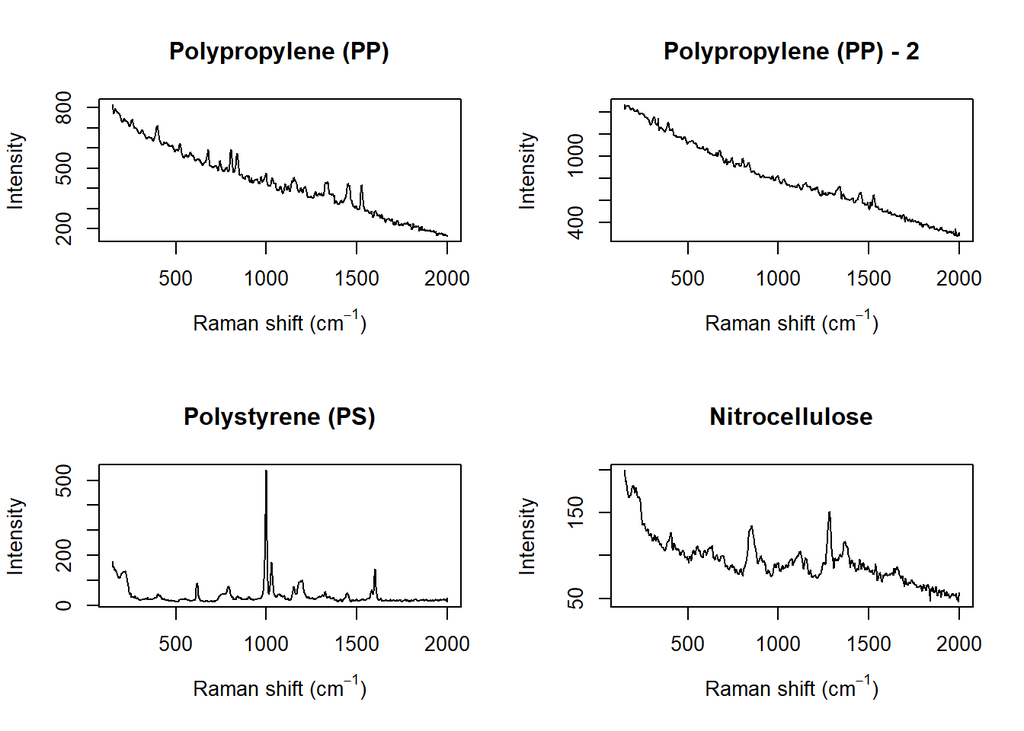

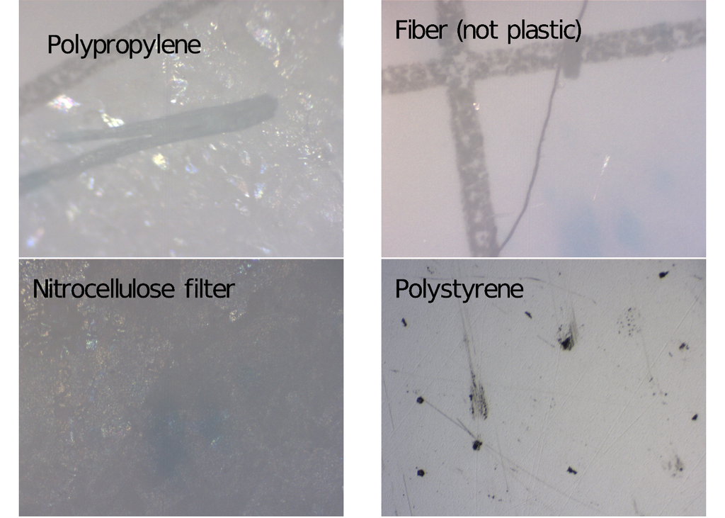

## Ask Marie and Enora

- What kind of tray/dish they use to out their filter on how do they do their analysis with the particle finder
  - what kind of settings?
    - only laser 785?
    - for how long? (We tried 10 sec.)
    - what kind of particle size do they detect? Only down to 335 or smaller?
- Will the particle finder also make a scan of all the organic material?
  - it should be all digested then?!

## Ideas of collaboration between Hafró and Biopol on MP

- Biopol is well equipped with regards to MP sampling, digestion and preparation of samples
- Biopol lacks a good analytical instrument (Raman)
- Lack of aim
  - what do we want to see or prove?
  - sampling locations?
  - particle size (sampling method, Nishkin/Manta/plankton net)?
  - sampling matrix (biota/sediment/water)?
- Hafró could help with analysis of the sample by Raman
- Hafró could assist with ideas about the aim of the study
  - do we want to publish a report on sample processing or report on MP in Icelandic waters?
  - do we need to apply for funding?
- Jóhann is trying to involve another person (Lisa) in the project who could possibly take over his work.
- Hafró has not given MP’s much consideration yet but Lisa thinks it’s necessary for Hafró to build a clean working environment in the new facilities to be up to standards for publishing on MP.